# Dinosaur sizes

Size is an important aspect of **dinosaur paleontology**, of interest to both the general public and professional scientists. Dinosaurs show some of the most *extreme* variations in size of any land animal group, ranging from tiny hummingbirds, which can weigh as little as two grams, to the extinct titanosaurs, which could weigh as much as 60–100 t (66–110 short tons). The latest evidence suggests that dinosaurs’ average size **varied** through the Triassic, early Jurassic, late Jurassic and Cretaceous periods, and dinosaurs probably **only became widespread** during the early or mid Jurassic.

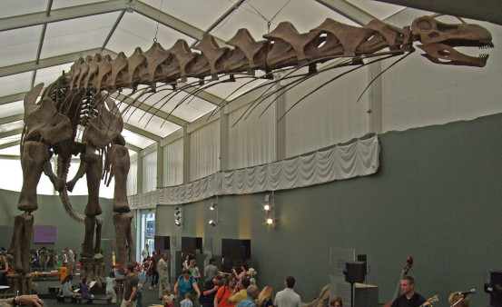

Reconstructed skeleton of the titanosaur Argentinosaurus huinculensis, often considered the largest-known dinosaur

> Reconstructed skeleton of the titanosaur Argentinosaurus huinculensis, often considered the largest-known dinosaur

## Record sizes

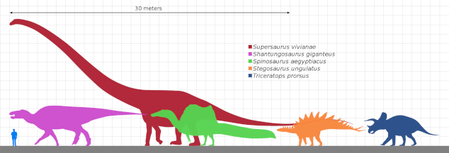

Scale diagram comparing a human and the largest-known dinosaurs of five major clades

> Scale diagram comparing a human and the largest-known dinosaurs of five major clades.

The sauropods were the longest and heaviest dinosaurs. For much of the dinosaur era, the smallest sauropods were larger than almost anything else in their habitat, and the largest were an order of magnitude more massive than anything else known to have walked the Earth since. Giant prehistoric mammals such as *Paraceratherium* and *Palaeoloxodon* (the largest land mammals ever discovered) were dwarfed by the giant sauropods, and only modern whales approach or surpass them in weight, though they live in the oceans.

One of the tallest and heaviest dinosaurs known from good skeletons is *Giraffatitan brancai*. Its remains were discovered in Tanzania between 1907 and 1912. Bones from several similar-sized individuals were incorporated into the skeleton now mounted and on display at the [Museum für Naturkunde Berlin](https://www.museumfuernaturkunde.berlin/de)

## Heaviest sauropodomorphs

1. *Maraapunisaurus fragilimus* : 79–120 t (87–132 short tons)
2. *Argentinosaurus huinculensis*: 65–100 t (72–110 short tons)
3. *Mamenchisaurus sinocanadorum*: 60–80 t (66–88 short tons)
4. *Patagotitan mayorum*: 52–77 t (57–85 short tons)
5. *Notocolossus gonzalezparejasi*: 45–75.9 t (49.6–83.7 short tons)

## Longest sauropodomorphs

- *Barosaurus lentus*: 25–48 m (82–157 ft)
- *Maraapunisaurus fragilimus*: 30.2–40 metres (99–131 ft)
- *Patagotitan mayorum*: 31–37 m (102–121 ft)
- *Supersaurus vivianae*: 32–35 m (105–115 ft)
- *Argentinosaurus huinculensis*: 30–35 m (98–115 ft)

**Source**: [Wikipedia](https://en.m.wikipedia.org/wiki/Dinosaur_size)